# Final Report

CO2 Offset Project Investigation

Abdallah Omari, Majd Shatara, Mansour Alhawwas, Sebastian Makrides

December 11, 2022

```r
library(tidyverse)
library(readxl)
library(here)
library(janitor)
library(ggplot2)
library(cowplot)
library(knitr)
library(tidyverse)
library(viridis)
library(ggrepel)
library(gganimate)
library(magick)
library(here)
library(plotly)

library(readxl)
library(janitor)
library(ggplot2)
library(knitr)
# Data Source

Voluntary_Registry_Offsets_Database_v5_April_2022 <- read_excel("data_raw/Voluntary-Registry-Offsets-Database--v5-April-2022.xlsx")
```

```r
clean_data <- read_excel("data_raw/Voluntary-Registry-Offsets-Database--v5-April-2022.xlsx", "PROJECTS",skip=3)

view(clean_data)
clean_raw_data <- clean_data %>%
    clean_names()%>%
    rename(continent = region)

view(clean_raw_data)

selected_data <- clean_raw_data %>%
select(continent,scope,voluntary_registry, total_credits_issued, total_credits_retired, total_credits_remaining,state)  %>%
    arrange(desc(total_credits_issued))

write.csv(clean_raw_data,
          here::here('data_processed','clean_data_processed'),row.names = FALSE)
```

# Background

## What is a Carbon Offset?

Carbon offsets are a type of program designed to help reduce greenhouse gas emissions and address anthropogenic climate change. They work by allowing individuals or organizations to offset their own emissions by funding projects that reduce greenhouse gas emissions in other parts of the world. When an individual or organization decides to purchase carbon offsets, they are essentially buying the right to claim that a specific amount of greenhouse gas emissions has been reduced or avoided elsewhere. This enables the purchaser to offset their own emissions and reduce the overall quantity of greenhouse gasses (GHG) being emitted into the atmosphere.

Carbon offsets are often purchased through carbon offset registries, which partner with project developers to offer a range of offset options. These companies typically provide information about the carbon offset projects they offer, including the number of emissions reduced and the location of the project.

These registries are broken down to illustrate the most active registries in terms of issuances in the plot below:

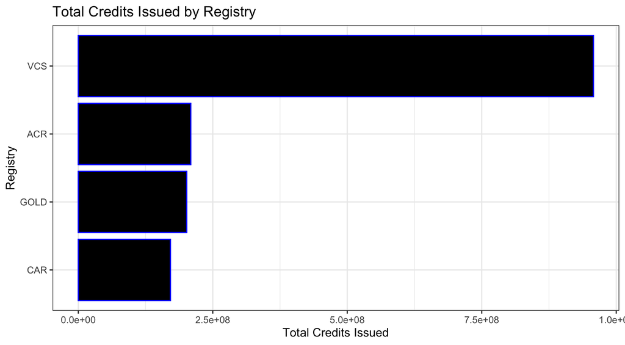

```r
chart_1 <-selected_data %>%
select(voluntary_registry, total_credits_issued)  %>%
    arrange(desc(total_credits_issued)) %>%
    na.omit()%>%
    group_by(voluntary_registry)%>%
    summarise_all(sum)

view(chart_1)

Registry <-chart_1 %>%
    ggplot()+
    geom_col(aes(x = total_credits_issued,y = reorder(voluntary_registry, total_credits_issued)),fill = "black", color ="blue")  +
    labs(x="Total Credits Issued",y="Registry") +
    ggtitle("Total Credits Issued by Registry")

Registry
```

As you can see VCS is the leader in credit issuance.

Additionally, these registries issue projects all around the world as demonstrated in the following figure that illustrates North America as the leader in credit issuance.

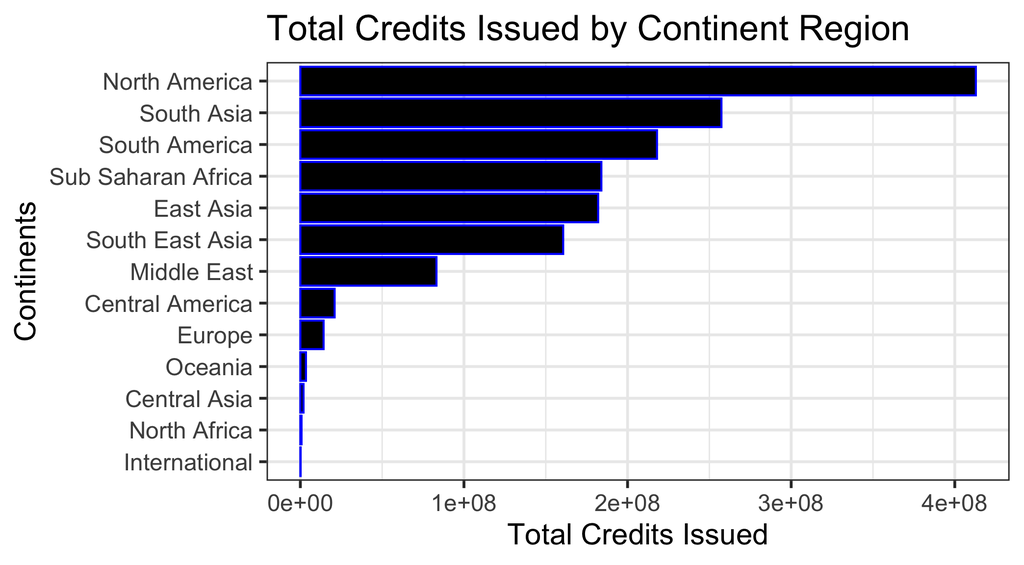

```r
theme_set(theme_bw(base_size =15))





## PLOT 2 PART 1
chart_2 <-selected_data %>%
select(continent, total_credits_issued)  %>%
    arrange(desc(total_credits_issued)) %>%
    na.omit()%>%
    group_by(continent)%>%
    summarise_all(sum)



chart_2 %>%
    ggplot()+
    geom_col(aes(x = total_credits_issued,y = reorder(continent, total_credits_issued)),fill = "black", color ="blue")  +
    labs(x="Total Credits Issued",y="Continents") +
    ggtitle("Total Credits Issued by Continent Region")
```

Although increasingly popular there are a growing number of critics of carbon offset programs that fear offset credits may not be providing the emission reductions they claim to offer. Off-set projects are difficult to verify and may not always deliver the promised emissions reductions. These criticisms also extend to the principle that offsets can be used as a way for companies to continue emitting greenhouse gasses without facing consequences. This report aims to address such issues.

Despite these criticisms, carbon offsets remain a popular tool for addressing climate change and reducing greenhouse gas emissions. By allowing individuals and organizations to offset their own emissions, they provide a way for people to take action on climate change while continuing to live their lives in the same way.

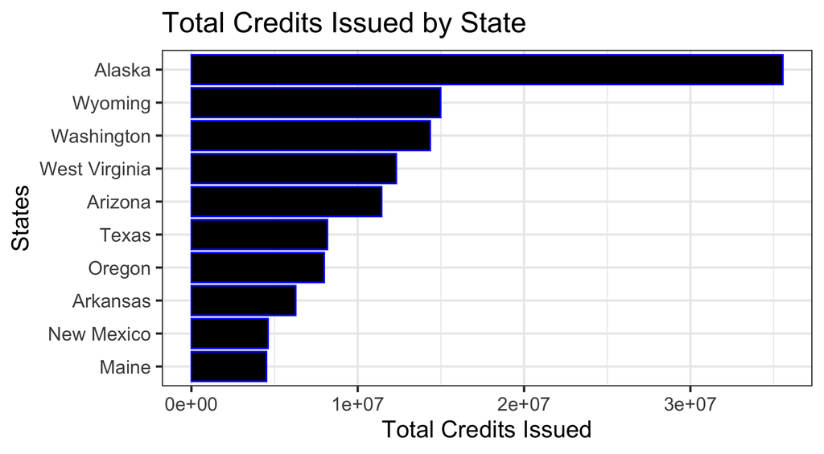

```r
## PLOT 2 PART 2

chart_3 <-selected_data %>%
select(state, total_credits_issued)  %>%
    arrange(desc(total_credits_issued)) %>%
    na.omit()%>%
    slice_head(n=15)%>%
    group_by(state)%>%
    summarise_all(sum)

chart_3$state <-str_to_title(chart_3$state)

view(chart_3)

chart_3 %>%
    ggplot()+
    geom_col(aes(x = total_credits_issued,y = reorder(state, total_credits_issued)),fill = "black", color ="blue")  +
    labs(x="Total Credits Issued",y="States")+
    ggtitle("Total Credits Issued by State")
```

# Research Question

What are the major trends within carbon offset project credit sales in terms of issuance, location, lifetime, active status, and project scope, and how can these metrics be used to evaluate the validity of the emission reductions advertised by offset credit providers?

# Data Sources

The main data source used for this project was the University of California Berkeley’s Voluntary Registry Offsets Database(VROD). https://gspp.berkeley.edu/faculty-and-impact/centers/cepp/projects/berkeley-carbon-trading-project/offsets-database

The VROD contains data on carbon management projects launched under the four largest voluntary offset project registries: American Carbon Registry (ACR) Climate Action Reserve (CAR) Gold Standard (GS) Verra (VCS)

In the plots below, we show the different registries and their usages throughout the years:

```r
## PLOT 3

chart_5 <-selected_data %>%
select(voluntary_registry, total_credits_issued,total_credits_remaining,total_credits_retired)  %>%
    arrange(desc(total_credits_issued)) %>%
    na.omit()%>%
    group_by(voluntary_registry)%>%
    summarise_all(sum)

chart_5 %>%
    pivot_longer(cols = total_credits_issued:total_credits_retired,
             names_to = "Credits",
             values_to = "total_credits_issued")
```

```
#> # A tibble: 12 × 3
#>    voluntary_registry Credits                 total_credits_issued
#>    <chr>              <chr>                                  <dbl>
#>  1 ACR                total_credits_issued               209026513
#>  2 ACR                total_credits_remaining             93076942
#>  3 ACR                total_credits_retired              115949571
#>  4 CAR                total_credits_issued               171265408
#>  5 CAR                total_credits_remaining             49741106
#>  6 CAR                total_credits_retired              121524302
#>  7 GOLD               total_credits_issued               201552836
#>  8 GOLD               total_credits_remaining             93486861
#>  9 GOLD               total_credits_retired              108065975
#> 10 VCS                total_credits_issued               957662904
#> 11 VCS                total_credits_remaining            481612863
#> 12 VCS                total_credits_retired              476050041
```

[figure not shown]

```r
## NEW CHART EXTRA



## NEW CHART PLOT 3 PART 1

xx <- pivot_longer(chart_5, cols = -voluntary_registry, names_to = "variable", values_to = "value")
view(xx)

barplot(xx$value,
  names.arg = paste(xx$voluntary_registry),
  col = c("blue", "red", "yellow"),
  main = "Registries vs Credit Types since 1998",
  xlab = "Yellow = Total Credits Remaining, Red = Total Credits Retired, Blue = Total Credits Issued",
  ylab = "Values",
  space = 0.2

)
```

The plot above, ‘Registries Vs. Credit Types since 1998’ indicates the amount of credits issued for each registry. The registries on the x-axis are (ACR - American Carbon Registry, CAR - Climate Action Reserve, GOLD - Gold Standard, and VCS - Verra). Each registry has three columns to represent the total credits remaining, total credits retired, and total credits issued. It can be derived from the plot that the Verra registry has the highest amounts of credits issued, retired, and remaining since 1998; accordingly, the Gold Standard and the American Carbon Registry have almost the same amount of credits issued.

[figure not shown]

```r
## NEW CHART  PLOT 3 PART 2
filtered_yr <- filter(clean_raw_data, first_year_of_project>2016)
view(filtered_yr)

filtered_yr2 <-filtered_yr %>%
    select(voluntary_registry,total_credits_issued,total_credits_remaining,total_credits_retired)  %>%
    group_by(voluntary_registry)%>%
    arrange(desc(total_credits_issued)) %>%
    na.omit()%>%
    summarise_all(sum)

view(filtered_yr2)

yy <- pivot_longer(filtered_yr2, cols = -voluntary_registry, names_to = "variable", values_to = "value")

view(yy)

barplot(yy$value,
  names.arg = paste(yy$voluntary_registry),
  col = c("blue", "red", "yellow"),
  main = "Registries vs Credit Types since 2017",
  xlab = "Yellow = Total Credits Remaining, Red = Total Credits Retired, Blue = Total Credits Issued",
  ylab = "Values",
  space=0.1
)
```

## Controversy

Over-crediting and misrepresentation of the benefits of offset projects often occur when offset project developers forecast project efficacy incorrectly in any of the following ways:

### Additionality

GHG reductions are additional if they would not have occurred in the absence of a market for offset credits. If the reductions would have been regardless of the financing hen they are considered non-additional. If an offset project’s associated GHG reductions are not additional, then purchasing of the offset credits would make no difference environmentally and would be of no value.

### Baseline Emissions

Baseline emissions are the emissions that would have occurred in the absence of demand for offset credits which enables credits to be generated beyond whatever sustainable changes occur as a result of the project.

### Actual Emissions

A project’s GHG reductions are quantified by comparing the actual emissions that occur after the project is implemented to its predicted baseline emissions. Like baseline emissions, errors in estimation can occur for actual emissions for an offset project. When an underestimation of actual emissions occurs it results in the overestimation of GHG reductions. Such estimation errors are commonly associated with measurement error and uncertainty with regard to the carbon sequestration capabilities of projects.

### Leakage

Oftentimes an offset project can have both intentional and unintentional impacts on emissions. When offset projects do not consider the potential of the project causing GHG emission increases whether directly or indirectly then there is a risk of GHG reductions being overestimated. These unintentional emission increases that occur outside of the scope of a project are known as “leakage.”

### Forward Crediting

Offset projects can be misrepresented when forward crediting occurs when an offset credit is issued prior to the completion of an offset project. When project developers “forward credit” a project due to their expectation of completing the project in the future in cases where the offset project under-performs it can result in the over-issued credits ending up on the market for sale.

## Permanence

Issues regarding the permanence of a carbon offset credit occur when there is a risk of the carbon reduction generated by the project being reversed due to human activities. For instance, if a reforestation project generates offset credits and the forest gets converted into farmland a few years later then the project has low permanence. Project permanence can also be impacted by indirect human effects such as anthropocentric climate change which can undo the benefits being generated by offset projects via unintentional consequences such as higher occurrences of wildfires. Such issues with permanence are typically mitigated by establishing buffer pools for credits but their ability to address such reversals of offset project benefits is dependent on their size.

# Addressing Credit Quality Via Demand

One of the major issues with carbon offsets is the lack of proper data collection, quality assurance, and verification of their effectiveness.

To address such issues the current consensus among environmental NGOs, academia, and corporate sustainability initiatives is to prioritize the procurement of offsets projects that facilitate carbon removals. Such differentiations in the type of mitigation an offset provides and prioritization of projects will help ensure the quality of the environmental benefits being purchased.

## Mitigation Types

However, as you can see most projects are not removals but rather reductions or a mixture of both. The plot below shows impermanent removal, mixed, and reduction types and how many credits they have remaining throughout the years.

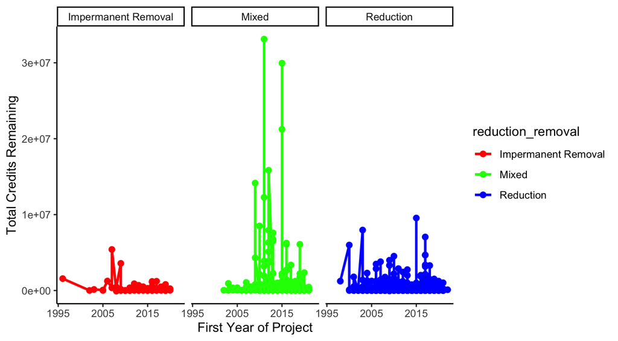

```r
library(tweenr)
library(gifski)
library(gganimate)

top_market_trend <- clean_raw_data %>%
    group_by(scope) %>%
    slice(1:4)

filtered_market_trend <- clean_raw_data %>%
    filter(scope %in% top_market_trend$scope)

view(filtered_market_trend)

library(transformr)

z <- ggplot(filtered_market_trend,
       aes(x = first_year_of_project, y = total_credits_remaining,
           color = reduction_removal)) +
    scale_color_discrete(limits = top_market_trend$reduction_removal)+
  geom_line(size = 1) +
  geom_point(size = 2) +
  theme_classic()+
  xlab("First Year of Project") +
  ylab("Total Credits Remaining")+
    facet_grid(~reduction_removal)+
    scale_color_manual(values = c("red", "green", "blue"))+
    scale_x_continuous(breaks = c(1995, 2005,2015))




z
```

As you can see from the figure above most of the credits that were issued and then retired the remaining credits were the lowest among removal projects despite them being the most robust type of program.

```r
data_sum <- clean_raw_data %>%
    filter(scope %in% c(
    'Household & Community', 'Chemical Processes', 'Agriculture', 'Forestry & Land Use', 'Waste Management', 'Waste Management','Carbon Capture &       Storage', 'Renewable Energy', 'Transportation')) %>%
    mutate(credit = total_credits_retired/total_credits_issued) %>%
            filter(
            !is.nan(credit)) %>%
    group_by(first_year_of_project) %>%
        mutate(
            average_credit = mean(credit)
        )

na.omit(data_sum)
```

```
#> # A tibble: 0 × 150
#> # Groups:   first_year_of_project [0]
#> # … with 150 variables: project_id <chr>, project_name <chr>,
#> #   voluntary_registry <chr>, arb_project <chr>, voluntary_status <chr>,
#> #   scope <chr>, type <chr>, reduction_removal <chr>,
#> #   methodology_protocol <lgl>, continent <chr>, country <chr>, state <chr>,
#> #   project_site_location <chr>, project_developer <chr>,
#> #   total_credits_issued <dbl>, total_credits_retired <dbl>,
#> #   total_credits_remaining <dbl>, first_year_of_project <dbl>, …
```

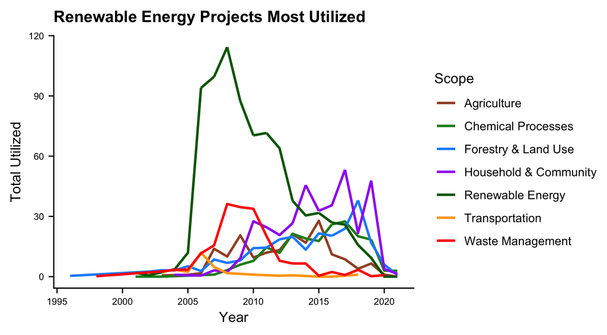

```r
voluntary_plot <- data_sum %>%
    group_by(first_year_of_project, scope) %>%
    mutate(credit = sum(credit))
    ggplot(voluntary_plot,
    ) +
     geom_line( aes(x = first_year_of_project , y = credit,
     color = scope),
     size = 1) +
    scale_color_manual(values = c(
    'sienna', 'forestgreen', 'dodgerblue', 'purple', 'darkgreen', 'orange' ,'red', 'cyan')) +
    theme_half_open(font_size = 18) +
    theme(text = element_text(size = 12),
          axis.text.x = element_text(size = 8),
        axis.text.y = element_text(size = 8))+
    labs(
    x     = 'Year',
    y     = 'Total Utilized',
    color = 'Scope',
    title = 'Renewable Energy Projects Most Utilized')
```

In this plot we showcased the total utilized values over time for each scope. We calculated the total utilized by dividing the total credits retired by the total credits issued assigning that value to a new variable, and grouping it by the scope values. We can see from this plot that the scope that is utilized the most is found in renewable energy, and that the least utilized was the transportation scope. We can also see that over time all the scopes collectively decrease.

# Conclusions

Carbon offsets can serve as a useful tool for companies, universities, individuals, and others who wish to meet voluntary emissions targets via the offsetting of their GHG emissions. Based on the data we analyzed and the data visualizations generated it is evident that across the top carbon offset registries there appears to be a trend of carbon offset credits advertising emission mitigations that are far higher than what they are capable of producing based upon the trends we analyzed in credit type and usage. Promoting a shift towards projects that are within the removal category will help to ensure the validity of the carbon mitigations associated with the sale of a carbon credit. To best achieve net zero strategies that are driving increased demand for carbon credits, buyers need to prioritize the purchasing of removal projects due to the certainty around their carbon benefits. However, mixture and reduction category projects serve an important purpose in providing ecosystem services and benefits that may not technically be linked to carbon reductions.

# Data Dictionary

```r
# Data Dictionary

Data_Dictionary <- read_excel("data_raw/Data_Dictionary.xlsx")
kable(Data_Dictionary)
```

| PROJECTS | Column Header | Details & Description | From Registry Data? |
| --- | --- | --- | --- |
| A | Project ID | The identification number given by the registries. We added “VCS” to the Verra ID numbers. | yes |
| B | Project Name | Name of the project on the registry. | yes |
| C | Voluntary Registry | The project registry that issues and tracks offset credits. | No |
| D | ARB Project | Yes = all projects listed on ARB’s Issuance & Retirements table or listed as ‘proposed’ or ‘active’ ARB projects by the registries. | No |
| E | Voluntary Status | The status of the project on the voluntary market as designated by the registry. | yes |
| F | Scope | Each project falls under a scope according to the definitions in this document. | No |
| G | Type | Each project is categorized by a type according to the definitions in this document. | No |
| H | Reduction / Removal | Each project type is categorized as Reductions, Permanent removals, Impermanent removals, or Mixed. Removals are project types that primarily draw carbon out of the atmosphere. Mixed are project types… | No |
| I | Methodology / Protocol | Defines the eligibility, emissions calculations, and monitoring requirements for specific project types. They can be found at the links included on READ FIRST. Methodology is synonymous with protocol. | yes |
| J | Region | Regions are defined in the World Regions tab. There are a group of projects under the Fleet Efficiency subtype which are not registered in any particular country. These projects increase fuel efficien… | No |
| K | Country | The country where the project takes place. Projects listed as “International” include reducing emissions from international shipping and projects taking place in multiple countries. | yes |
| L | State | The state or province where the project takes place. | yes |
| M | Project Site Location | More details on the location of the project. | yes |
| N | Project Developer | The person or organization responsible for developing the offset project. This is often the facility owner, project owner, or offset consultant. | yes |
| O | Total Credits Issued | The total number of credits issued by the registry from the start of the project. Complete downloaded registry issuance tables can be found in the registry Issuances tabs. These figures are somewhat i… | No |
| P | Total Credits Retired | The total number of credits retired or cancelled from the start of the project. Credits are marked as retired once an owner notifies the registry that credits are being used towards a compliance or vo… | No |
| Q | Total Credits Remaining | The difference between credits issued and credits retired. Not all credits remaining are available for purchase, since some buyers may use them towards a climate commitment without notifying the regis… | No |
| R | First Year of Project | The first year when credited reductions/removals occurred, marked by the end of the first reporting period. | No |
| S-AS | Credits Issued by Vintage Year (reductions/removals occurring in: 1996 - 2022) | Credits issued by year when reductions/removals occurred, often called the vintage year, taken as the year of the end of the reporting period. To see the year when credits are issued, refer to columns… | No |
| AT-BT | Credits Retired in 1996 - 2022 | Lists credits retired/canceled by the retirement year. Retirements from ARB projects sum voluntary retirements listed in the registries and compliance retirements listed in ARB’s issuance table. ARB r… | No |
| BU | Credits Retired in Year Unknown | Lists credits retired with no retirement date, including ARB compliance credits retired by Quebec and retired voluntarily, and Gold Standard credits recorded as assigned (for credits issued in future … | No |
| BV-CV | Credits remaining by vintage: 1996 - 2022 | Lists credits remaining and available in each issued vintage year. We reflect the registries as is, thus a few vintages have negative remaining values due to differences between their registry issuanc… | No |
| CW | Project Owner | The organization, company, or individual who owns the offset project. | yes |
| CX | Offset Project Operator | The organization, company, or individual which operates the offset project. | yes |
| CY | Authorized Project Designee | The organization, company or individual that has first right of refusal for credits issued. | yes |
| CZ | Verifier | Each registry requires a certified third party to verify that the project complies with the requirements of the protocol and that the claimed reductions are monitored and reported as per the requireme… | yes |
| DA | Estimated Annual Emissions Reductions | Some registries note the emissions reductions that the developer expects to produce annually as submitted in early project documents. | yes |
| DB | PERs (Credits Issued in Future Years) | Lists credits that are ex-ante, which are credits issued before the carbon emission reductions are realized. Reforestation and afforestation projects, for example, may sell credits for expected future… | No |
| DC | Registry / ARB | For filtering and sorting purposes, ARB projects (including all projects listed on ARB’s Issuance & Retirements table or listed as ‘proposed’ or ‘active’ ARB projects by the registries) are listed in … | No |
| DD | ARB Project Detail | Some of the projects from the ACR, CAR, and Verra registries are also registered as compliance offsets under the California Air Resources Board’s (ARB’s) offset program and can be used by California e… | No |
| DE | Project Listed | The date that the project was listed on the registry, declaring the project’s intention to generate carbon offset credits with a final version of the project design document. | yes |
| DF | Project Registered | The date that the project was registered as a registry offset project. | yes |
| DG | ARB ID | The California Air Resources Board assigned each of its projects with its own ID number. | yes |
| DH | CCB / Certifications | Verra’s Climate, Community & Biodiversity (CCB) Standards independently verify carbon offsets for other co-benefits related to conserving biodiversity and supporting local communities. Their ongoing s… | yes |
| DI | Project Type | The registry’s designation of type/sector as downloaded from the registry website. | yes |
| DJ | Registry Documents | Link to the registry site where you can download project documents. | No |
| DK | Project Website | External project website. | No |
| DL-EL | Credits Issued in 1996 - 2021 | Credits issued by issuance year. To see the year when the credited reductions/removals occurred by reporting period (vintage), refer to columns Q-AQ. It can take two years or more between the end of a… | No |
| EM | Notes from Registry | Notes from the registry. | yes |
| EN | Notes from Berkeley Carbon Trading Project | Notes were added by our team. Here we share unique attributes, findings, and context discovered during our data processing. | No |
| EO | Date added to database | The database version and release date when the project was added. | No |
| EP | * rows have equations | The starred rows hold equations we used to aggregate data. Equations differ by registry. We only include one or two rows with the formulas for each registry and hard code all other values to increase … | No |

# References

1-https://gspp.berkeley.edu/assets/uploads/page/VROD-Calculations.pdf

2-https://gspp.berkeley.edu/assets/uploads/page/VROD-ScopesTypes-v6.pdf

3-https://gspp.berkeley.edu/faculty-and-impact/centers/cepp/projects/berkeley-carbon-trading-project/offsets-database

4-https://www.carbon-direct.com/insights/assessing-the-state-of-the-voluntary-carbon-market-in-2022

5-https://www.offsetguide.org/high-quality-offsets/avoiding-overestimation/#_ftn1

6-https://www.offsetguide.org/high-quality-offsets/additionality/